# STATS 531 Final Project

Using Different Model On Fitting Beaver Population

Apr 17, 2016

# 1.The Introduction of the project

This project is mainly concerning using different model to fit the population of beaver, which is a kind of mammal living around the river. Since Beaver is the protected animals, thus studying the population of Beaver is kind of useful here. We are mainly concerning to use ARIMA model and POMP model for the population. For the POMP part, we are trying to use Ricker model, Hassell model and the blowflies model in our experiments.  
Generally speaking, there are several things we are going to do in our project.  
1.Basic time series analysis about beaver population.  
2.Fitting ARIMA model for beaver population.  
3.Fitting POMP model for beaver population with different models.

# 2.Introduction to the original data

For our data, we get the data from [here](http://www3.imperial.ac.uk/cpb/databases/gpdd). Our dataset is No.9721, which is the population of castor canadensis beaver. Since it is really hard to get the population data of animals with specific restriction, thus the data here is not the best one, but the one we can use.  
First of all, let’s look at the plot of our data.

```r
library(pomp)
library(forecast)
library(mFilter)
```

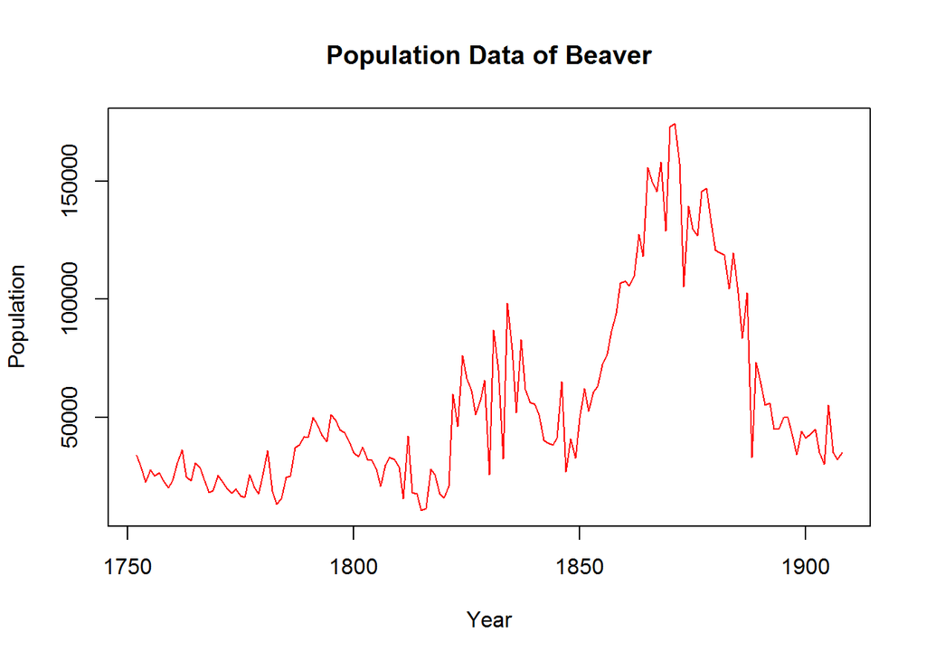

```r
library(plyr)
library(reshape2)
library(ggplot2)
library(doParallel)
Org_Data = read.csv("Beaver.csv")
plot(Org_Data[,-1],type = "l", main = "Population Data of Beaver", col = "red")
```

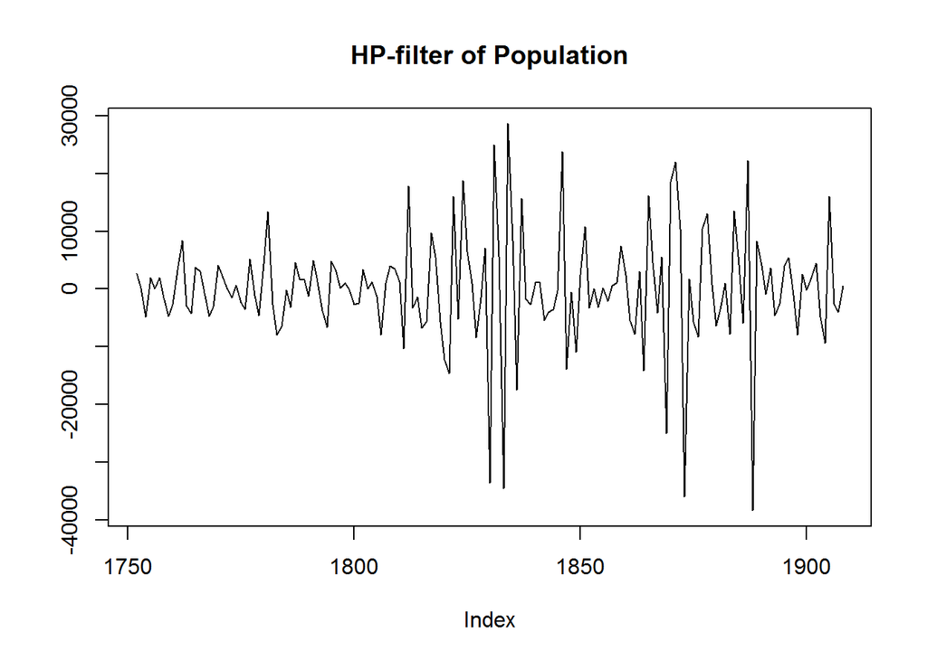

```r
Org_Data_HP <- hpfilter(Org_Data$Population, freq=10,type="lambda",drift=F)$cycle
plot(Org_Data$Year,Org_Data_HP,type="l",xlab="Index",ylab="", main = "HP-filter of Population")
```

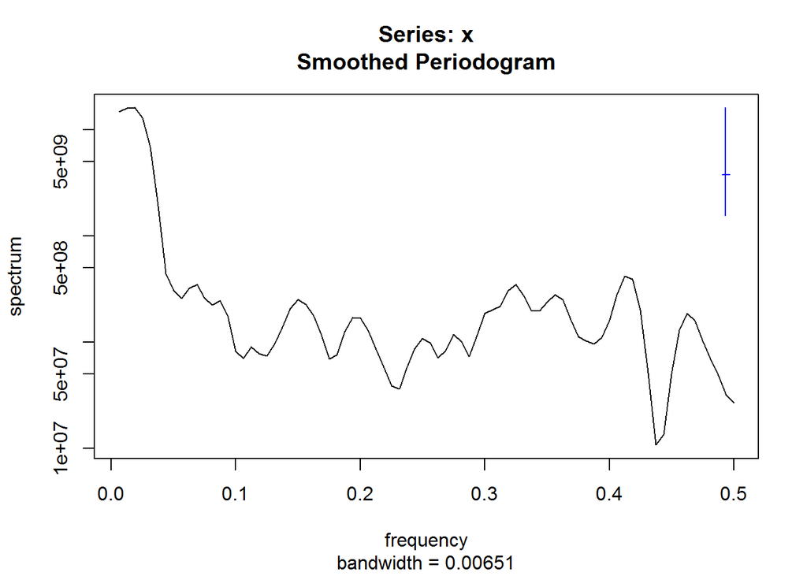

```r
Org_Data_Unmodified = Org_Data

spectrum(Org_Data_Unmodified$Population,span = c(3,3))
```